# Project Report: Pair Trading Strategies for BIST30 Companies

**Prepared by:**

Gamze Gür

Zeynep Sude Karakuş

Ahmet Selim Gül

## Introduction

This project focuses on analyzing hourly stock price data of BIST30 companies to find the highly correlated stocks, develop pair trading strategies and assess their effectiveness.

## Methodology

### Data Collection

Hourly stock price data of BIST30 companies for 2018-2019 was collected and used for analysis.

### Pair Selection

Stocks exhibiting high correlation were identified through statistical analysis and 2 different pairs were selected for the simulation.

### Strategy Development

Two pair trading strategies were developed:

1. **Part 1:** Simple Linear Regression Model:
   - Training data was used to create a simple linear regression model between the selected stock pairs.
2. **Part 2:** Advanced Time Series Model:
   - An advanced time series model was developed to further analyze the chosen stock pairs.

### Simulation

Stock prices in 2020 were used for the simulation. Simulation started with an initial capital of 1 dollar. Buy and sell decisions were given according to the models. At the end of the year, the profit was calculated.

## Part 1

For Part 1, python was used.

```python
# import statements
import pandas as pd
import numpy as np
import matplotlib.pyplot as plt
import statsmodels.api as sm
```

```python
# 2018-2019 stock price data is read, and the data is merged
df1 = pd.read_csv('Data/20180101_20180401_bist30.csv')
df2 = pd.read_csv('Data/20180402_20180701_bist30.csv')
df3 = pd.read_csv('Data/20180702_20180930_bist30.csv')
df4 = pd.read_csv('Data/20181001_20181230_bist30.csv')
df5 = pd.read_csv('Data/20181231_20190331_bist30.csv')
df6 = pd.read_csv('Data/20190401_20190630_bist30.csv')
df7 = pd.read_csv('Data/20190701_20190929_bist30.csv')
df8 = pd.read_csv('Data/20190930_20191229_bist30.csv')
merged_df = pd.concat([df1, df2, df3, df4, df5, df6, df7, df8])
```

```python
# Merged data is converted to wide format and timestamp object is converted to datetime object
merged_df_wide = merged_df.pivot(index='timestamp', columns='short_name', values='price')
merged_df_wide.reset_index(inplace=True)
merged_df_wide["timestamp"] = pd.to_datetime(merged_df_wide["timestamp"], format="%Y-%m-%dT%H:%M:%S%z")
```

```python
# Number of columns (number of stocks) in the data is assigned to a variable
num_columns = len(merged_df_wide.columns)
```

### Finding Highly Correlated Stocks

```
AKBNK GARAN 0.9671397199754379
AKBNK ISCTR 0.904586555958248
AKBNK SAHOL 0.950155637915807
AKBNK TTKOM 0.8918447144903212
AKBNK VAKBN 0.891915427602005
GARAN ISCTR 0.9018116538029108
GARAN SAHOL 0.899941504845156
ISCTR SAHOL 0.9218135917518007
ISCTR VAKBN 0.8997511129903448
ISCTR YKBNK 0.943875195489932
SAHOL TTKOM 0.8953064396572171
SAHOL VAKBN 0.9133634143462105
SAHOL YKBNK 0.9218910077428522
VAKBN YKBNK 0.8902153092652234
```

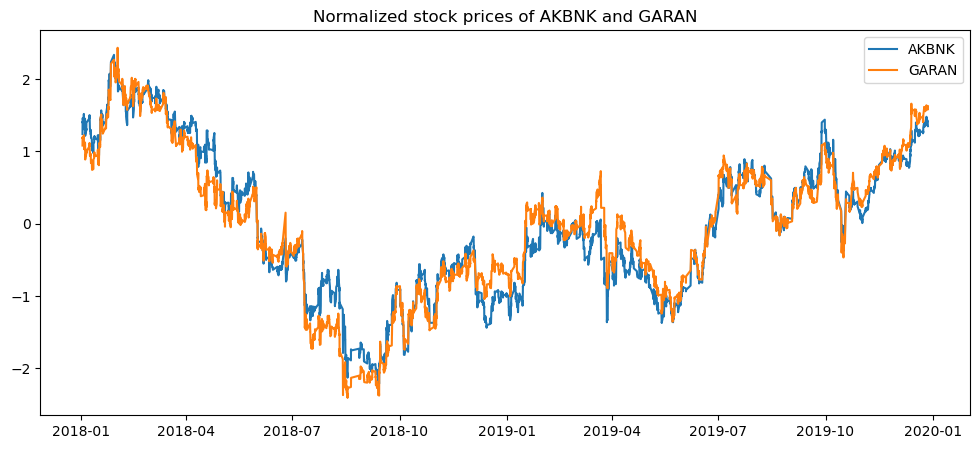

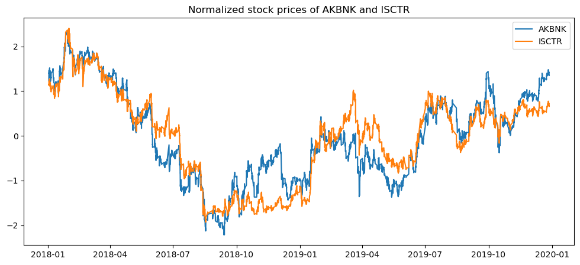

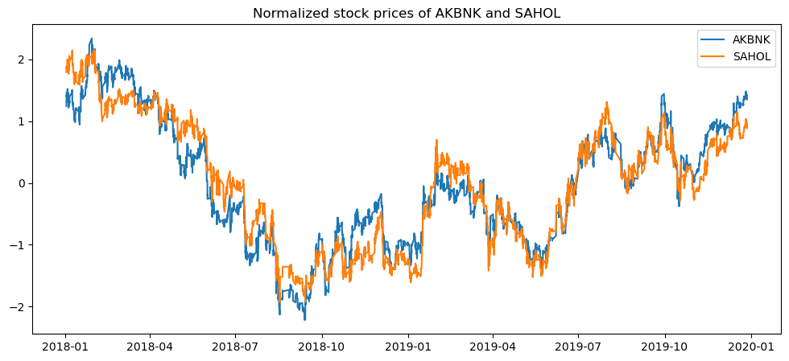

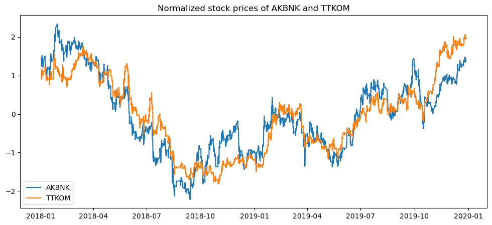

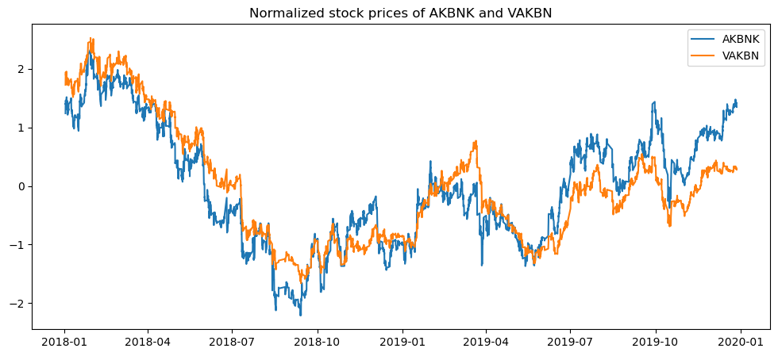

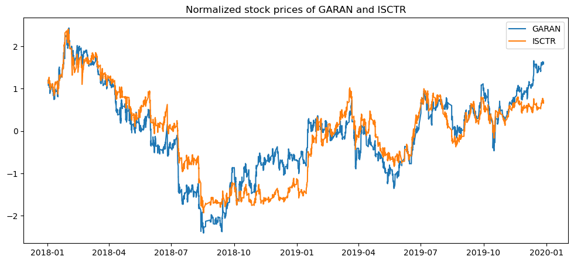

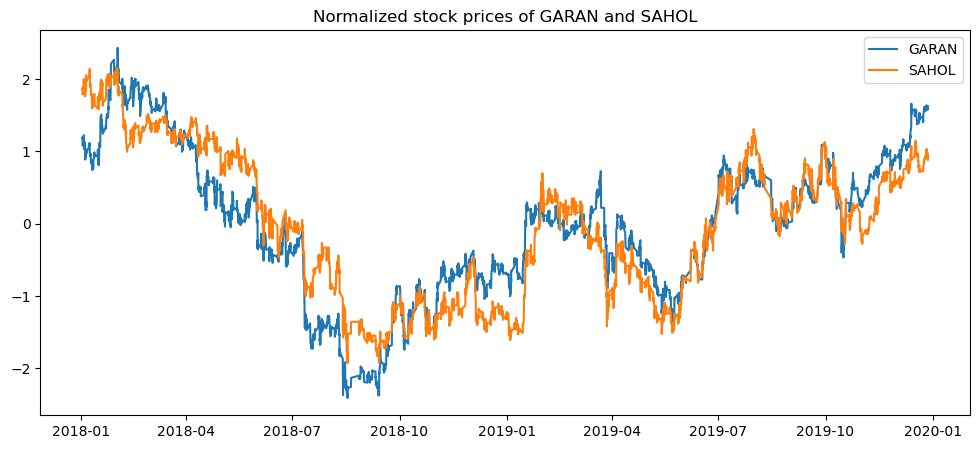

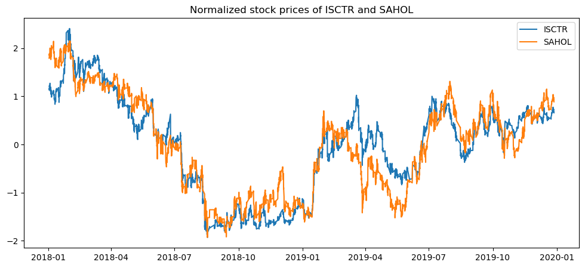

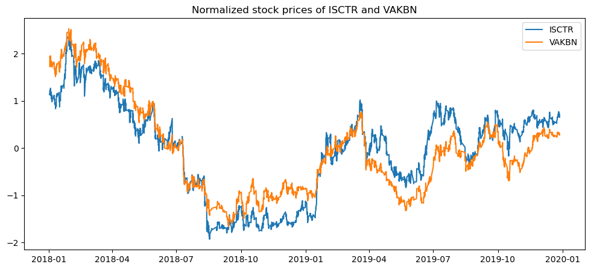

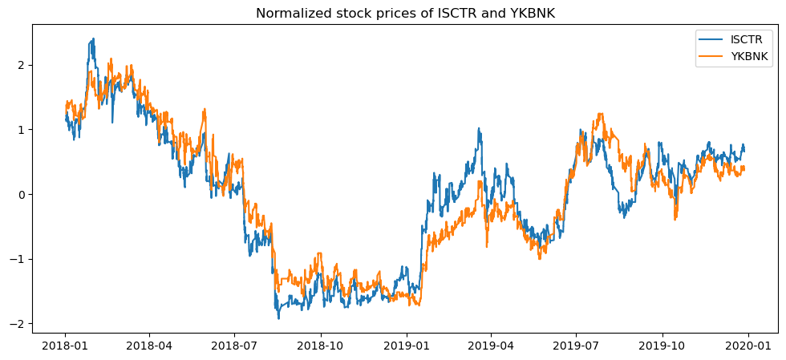

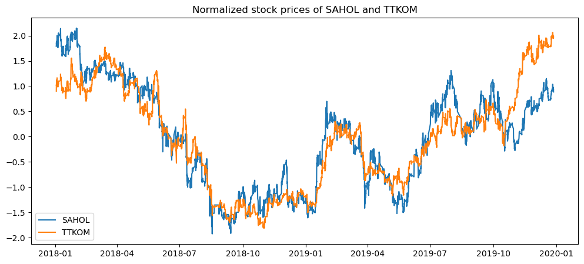

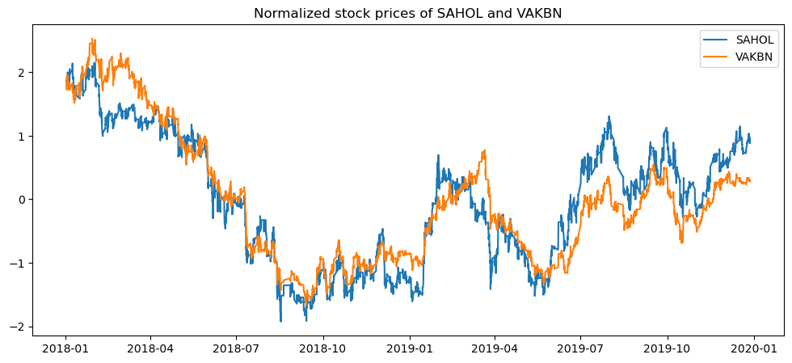

[2 more figures not shown]

```python
for i in range(1, num_columns):
    for j in range(i+1, num_columns):
        stock1 = merged_df_wide.columns[i]
        stock2 = merged_df_wide.columns[j]
        correlation = merged_df_wide[stock1].corr(merged_df_wide[stock2])
        if correlation > 0.89:
            print(stock1, stock2, correlation)
            fig, ax = plt.subplots(figsize=(12, 5))
            ax.set_title(f"Normalized stock prices of {stock1} and {stock2}")
            stock1_normalized = (merged_df_wide[stock1] - merged_df_wide[stock1].mean()) / merged_df_wide[stock1].std()
            stock2_normalized = (merged_df_wide[stock2] - merged_df_wide[stock2].mean()) / merged_df_wide[stock2].std()
            ax.plot(merged_df_wide["timestamp"], stock1_normalized, label=stock1)
            ax.plot(merged_df_wide["timestamp"], stock2_normalized, label=stock2)
            ax.legend()
```

To use in simulations, two pairs are selected arbitrarily. AKBNK-ISCTR and AKBNK-VAKBN are selected.

```python
# Selected stocks are assigned to variables.
AKBNK = merged_df_wide["AKBNK"]
ISCTR = merged_df_wide["ISCTR"]
VAKBN = merged_df_wide["VAKBN"]
```

### Creating Simple Linear Regression Models

Simple linear regression models predicting the price of ISCTR and VAKBN with respect to AKBNK are created. Then, residuals are calculated for both models. The residual standard deviations are calculated. The residuals are later used during the simulation on buy-sell decisions.

```
                            OLS Regression Results
==============================================================================
Dep. Variable:                  ISCTR   R-squared:                       0.818
Model:                            OLS   Adj. R-squared:                  0.818
Method:                 Least Squares   F-statistic:                 2.229e+04
Date:                Sat, 09 Dec 2023   Prob (F-statistic):               0.00
Time:                        17:27:58   Log-Likelihood:                 1993.5
No. Observations:                4953   AIC:                            -3983.
Df Residuals:                    4951   BIC:                            -3970.
Df Model:                           1
Covariance Type:            nonrobust
==============================================================================
                 coef    std err          t      P>|t|      [0.025      0.975]
------------------------------------------------------------------------------
const         -0.1351      0.016     -8.532      0.000      -0.166      -0.104
AKBNK          0.3980      0.003    149.311      0.000       0.393       0.403
==============================================================================
Omnibus:                      173.381   Durbin-Watson:                   0.006
Prob(Omnibus):                  0.000   Jarque-Bera (JB):              196.438
Skew:                          -0.443   Prob(JB):                     2.21e-43
Kurtosis:                       3.408   Cond. No.                         42.0
==============================================================================

Notes:
[1] Standard Errors assume that the covariance matrix of the errors is correctly specified.
-0.13507554407210776
0.39796182592508733
0.161796995974295
```

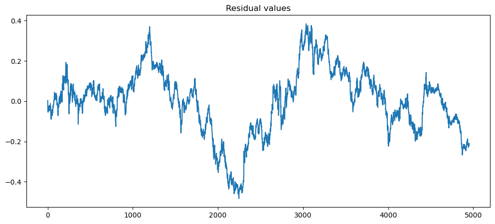

```python
# Simple linear regression model that calculates the expected price of ISCTR with respect to AKBNK.
# The predicted price of ISCTR = alfa1 * AKBNK + beta1
# Residuals are deviations from the predicted value.

X1 = sm.add_constant(AKBNK)
results1 = sm.OLS(ISCTR, X1).fit()
print(results1.summary())

beta1 = results1.params["AKBNK"]
alfa1 = results1.params["const"]
print(results1.params["const"])
print(results1.params["AKBNK"])

residuals1 = ISCTR - (alfa1 + beta1 * AKBNK)
residual_std1 = np.std(residuals1)
print(residual_std1)

residuals1.plot(figsize=(12, 5), title="Residual values")
```

```
                            OLS Regression Results
==============================================================================
Dep. Variable:                  VAKBN   R-squared:                       0.796
Model:                            OLS   Adj. R-squared:                  0.795
Method:                 Least Squares   F-statistic:                 1.926e+04
Date:                Sat, 09 Dec 2023   Prob (F-statistic):               0.00
Time:                        17:27:58   Log-Likelihood:                -3480.5
No. Observations:                4953   AIC:                             6965.
Df Residuals:                    4951   BIC:                             6978.
Df Model:                           1
Covariance Type:            nonrobust
==============================================================================
                 coef    std err          t      P>|t|      [0.025      0.975]
------------------------------------------------------------------------------
const         -1.7472      0.048    -36.546      0.000      -1.841      -1.654
AKBNK          1.1170      0.008    138.783      0.000       1.101       1.133
==============================================================================
Omnibus:                     1796.508   Durbin-Watson:                   0.005
Prob(Omnibus):                  0.000   Jarque-Bera (JB):              261.274
Skew:                          -0.156   Prob(JB):                     1.84e-57
Kurtosis:                       1.919   Cond. No.                         42.0
==============================================================================

Notes:
[1] Standard Errors assume that the covariance matrix of the errors is correctly specified.
-1.7472375126960022
1.1170148945009917
0.4885871339565562
```

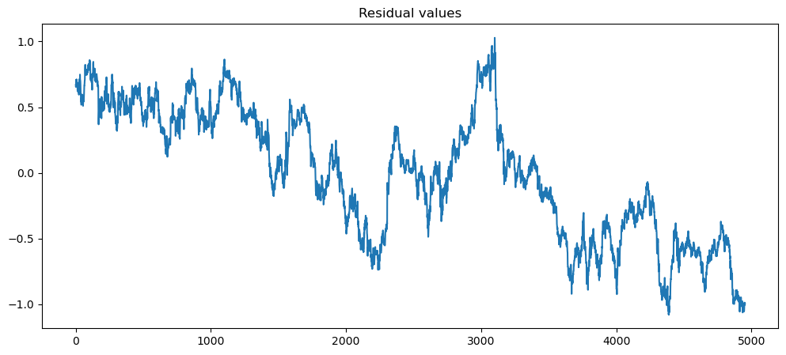

```python
# Simple linear regression model that calculates the expected price of VAKBN with respect to AKBNK.
# The predicted price of VAKBN = alfa3 * AKBNK + beta3
# Residuals are deviations from the predicted value.

X3 = sm.add_constant(AKBNK)
results3 = sm.OLS(VAKBN, X3).fit()
print(results3.summary())

beta3 = results3.params["AKBNK"]
alfa3 = results3.params["const"]
print(results3.params["const"])
print(results3.params["AKBNK"])

residuals3 = VAKBN - (alfa3 + beta3 * AKBNK)
residual_std3 = np.std(residuals3)
print(residual_std3)

residuals3.plot(figsize=(12, 5), title="Residual values")
```

```python
# 2020 stock price data is read, and the data is merged
# Merged data is converted to wide format and timestamp object is converted to datetime object
df9 = pd.read_csv('Data/20191230_20200329_bist30.csv')
df10 = pd.read_csv('Data/20200330_20200628_bist30.csv')
df11 = pd.read_csv('Data/20200629_20200927_bist30.csv')
df12 = pd.read_csv('Data/20200928_20201227_bist30.csv')
test_df_merged = pd.concat([df9, df10, df11, df12])
test_df_wide = test_df_merged.pivot(index='timestamp', columns='short_name', values='price')
test_df_wide.reset_index(inplace=True)
test_df_wide["timestamp"] = pd.to_datetime(test_df_wide["timestamp"], format="%Y-%m-%dT%H:%M:%S%z")
```

```python
# Selected stocks are assigned to variables.
AKBNK_test = test_df_wide["AKBNK"]
ISCTR_test = test_df_wide["ISCTR"]
VAKBN_test = test_df_wide["VAKBN"]
```

### Simulation

For each pair, a different simulation is run. Simulation logic is as follows:

1. At the start of the simulation, there is 1 unit of money. Number of shares bought from both stocks is 0.
2. At each hour, the stock price of the dependent variable (ISCTR or VAKBN) is predicted with respect to the stock price of independent variable (AKBNK). Then the residual is calculated by subtracting the predicted value from the real value.
3. For determining upper and lower control limits, mean residual at long term is estimated as 0. Then 1-sigma is used for control limits. Upper control limit = residual standard deviation. Lower control limit = -(residual standard deviation)
4. If the residual is higher than 0, which means the price of the dependent variable is higher than expected, there are two checks:
   - if there are dependent variable shares on hand, they are immediately sold.
   - if there is money on hand and the residual value is out of control limits, shares of independent variable are bought.
5. If the residual is lower than 0, which means the price of the dependent variable is lower than expected, there are two checks:
   - if there are independent variable shares on hand, they are immediately sold.
   - if there is money on hand and the residual value is out of control limits, shares of dependent variable are bought.

```
AKBNK-ISCTR pair trading:
Starting money: 1
Final money: 1.23
Profit: %22.90
```

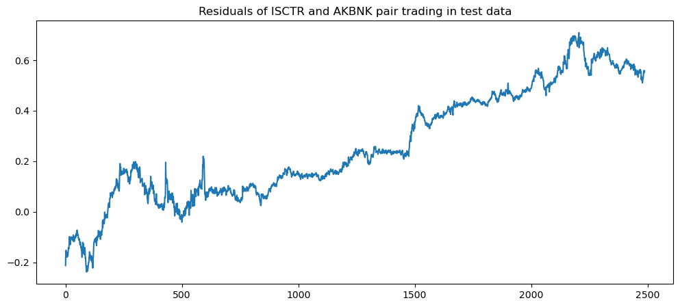

```python
# Simulation for AKBNK-ISCTR pair

test_residuals = ISCTR_test - (alfa1 + beta1 * AKBNK_test)
fig, ax = plt.subplots(figsize=(12, 5))
ax.set_title(f"Residuals of ISCTR and AKBNK pair trading in test data")
ax.plot(test_residuals)
money = 1
AKBNK_shares_bought = 0
ISCTR_shares_bought = 0

for i in range(len(test_residuals)):
    if test_residuals[i] > 0:
        if ISCTR_shares_bought > 0:
            money = money + ISCTR_shares_bought * ISCTR_test[i]
            ISCTR_shares_bought = 0
        if money > 0 and  test_residuals[i] > 1 * residual_std1:
            AKBNK_shares_bought = money / AKBNK_test[i]
            money = 0

    elif test_residuals[i] < 0:
        if AKBNK_shares_bought > 0:
            money = money + AKBNK_shares_bought * AKBNK_test[i]
            AKBNK_shares_bought = 0
        if money > 0 and test_residuals[i] < -1 * residual_std1:
            ISCTR_shares_bought = money / ISCTR_test[i]
            money = 0
money += AKBNK_shares_bought * AKBNK_test[len(test_residuals)-1] + ISCTR_shares_bought * ISCTR_test[len(test_residuals)-1]
print(f"AKBNK-ISCTR pair trading:\nStarting money: 1\nFinal money: {money:.2f}\nProfit: %{(money-1)*100:.2f}")
```

```
AKBNK-VAKBN pair trading:
Starting money: 1
Final money: 1.05
Profit: %5.44
```

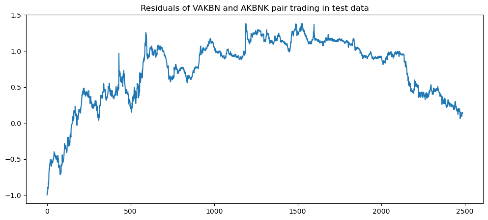

```python
# Simulation for AKBNK-VAKBN pair.

test_residuals = VAKBN_test - (alfa3 + beta3 * AKBNK_test)
fig, ax = plt.subplots(figsize=(12, 5))
ax.set_title(f"Residuals of VAKBN and AKBNK pair trading in test data")
ax.plot(test_residuals)
money = 1
AKBNK_shares_bought = 0
VAKBN_shares_bought = 0

for i in range(len(test_residuals)):
    if test_residuals[i] > 0:
        if VAKBN_shares_bought > 0:
            money = money + VAKBN_shares_bought * VAKBN_test[i]
            VAKBN_shares_bought = 0
        if money > 0 and  test_residuals[i] > 1 * residual_std3:
            AKBNK_shares_bought = money / AKBNK_test[i]
            money = 0

    elif test_residuals[i] < 0:
        if AKBNK_shares_bought > 0:
            money = money + AKBNK_shares_bought * AKBNK_test[i]
            AKBNK_shares_bought = 0
        if money > 0 and test_residuals[i] < -1 * residual_std3:
            VAKBN_shares_bought = money / VAKBN_test[i]
            money = 0
money += AKBNK_shares_bought * AKBNK_test[len(test_residuals)-1] + VAKBN_shares_bought * VAKBN_test[len(test_residuals)-1]
print(f"AKBNK-VAKBN pair trading:\nStarting money: 1\nFinal money: {money:.2f}\nProfit: %{(money-1)*100:.2f}")
```

### Analysis of Results

Both simulations returned a net profit nominally. However, in 2020, the yearly inflation was %14.97. The return of investment in AKBNK-ISCTR pair trading was higher than the inflation whereas the return of investment in AKBNK-VAKBN pair trading was lower than the inflation. This means that, although the method is effective in some cases, it should be improved. To improve the efficiency of the method, the stock data used for training should span more years. That way, temporary correlations and long term correlations can be differentiated.

# Task2

When incorporating time series analysis, there are various model options available, such as ARIMA models and Vector Auto-Regressive (VAR) models. For our pairs trading strategy, we have chosen to use the Vector Error Correction Model (VECM), an extension of the Vector Auto-Regressive (VAR) model, based on research. This modeling approach gives reliable estimates for multiple time series with long-term equilibrium relationships. The VECM assumes the existence of at least one cointegrating relationship, and with the Johansen Procedure, which will be employed below, we confirm that our pairs are cointegrated.*

*Schmidt, Arlen David. “Pairs Trading: A Cointegration Approach.” Honours Thesis, Discipline of Finance, 2009. University of Sydney. https://ses.library.usyd.edu.au/handle/2123/4072

```r
#Initially, data is read from CSV files using the readr library.

excel1 <- read_csv("C:/Users/lenovo/Downloads/20180101_20231121_bist30/20191230_20200329_bist30.csv", show_col_types = FALSE)
excel2 <- read_csv("C:/Users/lenovo/Downloads/20180101_20231121_bist30/20200330_20200628_bist30.csv", show_col_types = FALSE)
excel3 <- read_csv("C:/Users/lenovo/Downloads/20180101_20231121_bist30/20200629_20200927_bist30.csv", show_col_types = FALSE)
excel4 <- read_csv("C:/Users/lenovo/Downloads/20180101_20231121_bist30/20200928_20201227_bist30.csv", show_col_types = FALSE)

#The tidyverse library is loaded, and the spread function is used to pivot each read dataset. This transforms the data from long to wide format.

excel1_wide <- spread(excel1, key = short_name, value = price)
excel2_wide <- spread(excel2, key = short_name, value = price)
excel3_wide <- spread(excel3, key = short_name, value = price)
excel4_wide <- spread(excel4, key = short_name, value = price)


# The rbind function is used to concatenate all the widened datasets, creating a new dataset named all_data.
all_data <- rbind(excel1_wide, excel2_wide, excel3_wide, excel4_wide)
print(all_data)
```

| timestamp | AKBNK | ARCLK | ASELS | BIMAS | DOHOL | EKGYO | EREGL | FROTO | GARAN | GUBRF | HALKB | ISCTR | KCHOL | KOZAA | KOZAL | KRDMD | PETKM | PGSUS | SAHOL | SASA | SISE | TAVHL | TCELL | THYAO | TKFEN | TTKOM | TUPRS | VAKBN | VESTL | … |
| --- | --- | --- | --- | --- | --- | --- | --- | --- | --- | --- | --- | --- | --- | --- | --- | --- | --- | --- | --- | --- | --- | --- | --- | --- | --- | --- | --- | --- | --- | --- |
| 2019-12-30 06:00:00 | 7.0587 | 17.9631 | 4.8239 | 40.8388 | 1.6278 | 1.3164 | 6.7245 | 55.5085 | 9.8603 | 8.85 | 5.86 | 2.4619 | 18.2296 | 10.17 | 3.2075 | 2.4599 | 3.0833 | 84.75 | 7.9940 | 1.2373 | 4.8761 | 27.3503 | 12.2502 | 14.13 | 15.8365 | 5.9153 | 16.1815 | 5.14 | 10.3315 | … |
| 2019-12-30 07:00:00 | 7.0844 | 17.9808 | 4.8239 | 40.8738 | 1.6278 | 1.3257 | 6.7319 | 55.4292 | 9.9048 | 9.00 | 5.91 | 2.5245 | 18.2296 | 10.17 | 3.2139 | 2.4877 | 3.1000 | 84.85 | 8.0193 | 1.2260 | 4.8761 | 27.2014 | 12.2239 | 14.13 | 15.9923 | 5.9153 | 16.1688 | 5.21 | 10.0165 | … |
| 2019-12-30 08:00:00 | 7.0844 | 18.0516 | 4.8631 | 40.7346 | 1.6278 | 1.3347 | 6.7695 | 55.4292 | 9.9226 | 8.97 | 5.93 | 2.5323 | 18.2842 | 10.09 | 3.1841 | 2.4785 | 3.1083 | 84.75 | 8.0531 | 1.2470 | 4.9035 | 27.3503 | 12.1891 | 14.26 | 15.9759 | 5.9153 | 16.1561 | 5.21 | 10.0008 | … |
| 2019-12-30 09:00:00 | 7.1186 | 18.2109 | 4.9265 | 40.6649 | 1.6278 | 1.3347 | 6.7771 | 55.5482 | 10.0741 | 8.94 | 5.92 | 2.5362 | 18.3024 | 10.13 | 3.1799 | 2.4971 | 3.1250 | 84.75 | 8.0866 | 1.2404 | 4.8944 | 27.5365 | 12.1628 | 14.27 | 15.9841 | 5.8913 | 16.1688 | 5.23 | 10.0559 | … |
| 2019-12-30 10:00:00 | 7.1015 | 18.1577 | 4.9168 | 40.8738 | 1.6278 | 1.3439 | 6.8146 | 55.5085 | 10.0028 | 8.96 | 5.93 | 2.5167 | 18.3572 | 10.09 | 3.1820 | 2.5064 | 3.1250 | 84.85 | 8.0782 | 1.2437 | 4.8944 | 27.4993 | 12.1539 | 14.26 | 16.0579 | 5.8833 | 16.1815 | 5.24 | 10.0953 | … |
| 2019-12-30 11:00:00 | 7.0844 | 18.3347 | 4.9461 | 40.6649 | 1.6278 | 1.3439 | 6.8072 | 55.3894 | 9.9939 | 8.91 | 5.92 | 2.5049 | 18.3572 | 10.18 | 3.1820 | 2.4971 | 3.1083 | 84.65 | 8.0531 | 1.2340 | 4.9035 | 27.6482 | 12.1803 | 14.24 | 16.1399 | 5.8994 | 16.1308 | 5.28 | 10.0953 | … |
| 2019-12-30 12:00:00 | 7.1015 | 18.2640 | 4.9363 | 40.6127 | 1.6278 | 1.3439 | 6.8072 | 55.4292 | 10.0117 | 8.88 | 5.94 | 2.5128 | 18.3572 | 10.17 | 3.1841 | 2.4877 | 3.1167 | 84.55 | 8.0614 | 1.2324 | 4.8852 | 27.6110 | 12.1803 | 14.26 | 16.1645 | 5.8913 | 16.1181 | 5.28 | 10.0796 | … |
| 2019-12-30 13:00:00 | 7.1015 | 18.3347 | 4.9510 | 40.8738 | 1.6278 | 1.3439 | 6.7996 | 55.5482 | 10.0207 | 8.88 | 5.92 | 2.5128 | 18.3754 | 10.16 | 3.1799 | 2.4877 | 3.1167 | 84.55 | 8.0866 | 1.2340 | 4.8852 | 27.6482 | 12.1714 | 14.28 | 16.1480 | 5.9073 | 16.1434 | 5.28 | 10.1740 | … |
| 2019-12-30 14:00:00 | 7.0757 | 18.3524 | 4.9950 | 40.7868 | 1.6278 | 1.3347 | 6.7996 | 55.7464 | 9.9850 | 8.96 | 5.93 | 2.5206 | 18.3207 | 10.00 | 3.1373 | 2.4691 | 3.1167 | 84.50 | 8.0782 | 1.2276 | 4.8761 | 27.6110 | 12.1539 | 14.30 | 16.1070 | 5.8913 | 16.1181 | 5.33 | 10.1032 | … |
| 2019-12-30 15:00:00 | 7.0929 | 18.4055 | 5.0048 | 40.7868 | 1.6189 | 1.3439 | 6.7996 | 55.8260 | 9.9850 | 8.90 | 5.93 | 2.5128 | 18.3754 | 10.02 | 3.1353 | 2.4785 | 3.1167 | 84.55 | 8.0950 | 1.2276 | 4.8761 | 27.5924 | 12.1977 | 14.31 | 16.1070 | 5.8913 | 16.1181 | 5.32 | 10.0953 | … |

[output cut: 990 more lines]

```r
NA
NA
```

**PAIR1: AKBNK - VAKBN**

```r
#A new dataset named selected_columns is created, containing only the "timestamp," "VAKBN," and "AKBNK" columns.
selected_columns <- all_data[, c("timestamp", "VAKBN", "AKBNK")]
print(selected_columns)
```

| timestamp | VAKBN | AKBNK |
| --- | --- | --- |
| 2019-12-30 06:00:00 | 5.14 | 7.0587 |
| 2019-12-30 07:00:00 | 5.21 | 7.0844 |
| 2019-12-30 08:00:00 | 5.21 | 7.0844 |
| 2019-12-30 09:00:00 | 5.23 | 7.1186 |
| 2019-12-30 10:00:00 | 5.24 | 7.1015 |
| 2019-12-30 11:00:00 | 5.28 | 7.0844 |
| 2019-12-30 12:00:00 | 5.28 | 7.1015 |
| 2019-12-30 13:00:00 | 5.28 | 7.1015 |
| 2019-12-30 14:00:00 | 5.33 | 7.0757 |
| 2019-12-30 15:00:00 | 5.32 | 7.0929 |

[output cut: 990 more lines]

```r
#Differences in prices ("VAKBN" and "AKBNK") are calculated using the diff function, resulting in "VAKBN_diff" and "AKBNK_diff."
selected_columns$VAKBN_diff <- c(NA, diff(selected_columns$VAKBN))
selected_columns$AKBNK_diff <- c(NA, diff(selected_columns$AKBNK))
```

The appropriate lag value to create the model is determined using the “VARselect” function, and then the cointegration model is fitted using the “ca.jo “function. According to the output ,the null hypthesis stating that there is no cointegration relationship is rejected.

```r
#The vars and urca libraries are loaded. A VAR model is applied to the differenced series, and a cointegration test is conducted.

diff_data <- data.frame(data1 = selected_columns$VAKBN_diff , data2 = selected_columns$AKBNK_diff )
diff_data<-na.omit(diff_data)

var_select <- VARselect(diff_data, lag.max = 25, type = "both")
lags<-var_select$selection["AIC(n)"]

co_test <- ca.jo(diff_data, type = "trace", K = lags, ecdet = "const")
summary(co_test)
```

```
######################
# Johansen-Procedure #
######################

Test type: trace statistic , without linear trend and constant in cointegration

Eigenvalues (lambda):
[1] 0.07952960 0.07209391 0.00000000

Values of teststatistic and critical values of test:

           test 10pct  5pct  1pct
r <= 1 | 185.12  7.52  9.24 12.97
r = 0  | 390.14 17.85 19.96 24.60

Eigenvectors, normalised to first column:
(These are the cointegration relations)

              data1.l13    data2.l13   constant
data1.l13  1.0000000000  1.000000000  1.0000000
data2.l13 -0.7810082968 -6.976140027 -0.8715109
constant  -0.0001187058 -0.003716184 -0.4810359

Weights W:
(This is the loading matrix)

         data1.l13 data2.l13      constant
data1.d -1.2594609 0.1067116  3.040329e-19
data2.d -0.1469061 0.1566403 -2.649677e-18
```

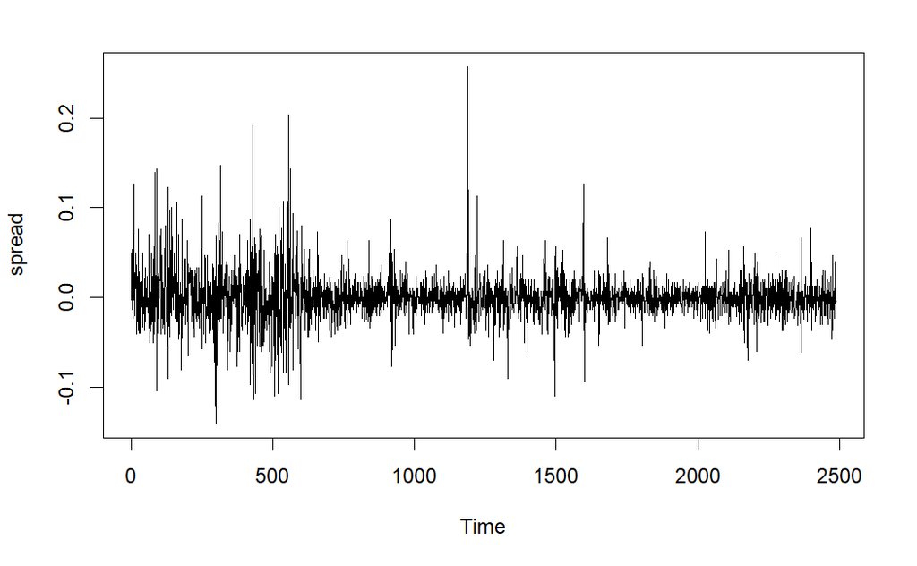

```r
#The spread is calculated using the VECM model, and a time series plot is generated to visualize the results.
vecm <- cajorls(co_test, r = 1)
diff_data_matrix <- as.matrix(diff_data)
spread <- diff_data_matrix %*% vecm$beta[1:2]
plot.ts(spread)
```

```r
selected_columns<-na.omit(selected_columns)
combined_data <- cbind(selected_columns, spread)
```

The Z-score of the spread is calculated to analyze how many standard deviations it is from the mean. The treshold value is defined according to 1 sigma limits.

```r
# Z-scores are computed, and reservoirs exceeding predetermined threshold values (-1 and 1) are filtered out.
combined_data$z_score <- (combined_data$spread- mean(combined_data$ spread)) / sd(combined_data$ spread)

upper_limit <- 1
lower_limit <- -1
out_of_control <- combined_data[combined_data$z_score > upper_limit | combined_data$z_score < lower_limit, ]

#Print out-of-control residuals, timestamps, and stock prices
print(out_of_control[, c("timestamp", "z_score", "VAKBN", "AKBNK")])
```

|  | timestamp | z_score | VAKBN | AKBNK |
| --- | --- | --- | --- | --- |
| 2 | 2019-12-30 07:00:00 | 1.897997 | 5.21 | 7.0844 |
| 6 | 2019-12-30 11:00:00 | 2.028951 | 5.28 | 7.0844 |
| 9 | 2019-12-30 14:00:00 | 2.670693 | 5.33 | 7.0757 |
| 12 | 2019-12-31 07:00:00 | 4.829165 | 5.47 | 7.1015 |
| 13 | 2019-12-31 08:00:00 | 1.649592 | 5.48 | 7.0587 |
| 17 | 2019-12-31 12:00:00 | 1.906241 | 5.48 | 6.9901 |
| 20 | 2019-12-31 15:00:00 | 1.393179 | 5.51 | 6.9473 |
| 21 | 2020-01-02 06:00:00 | -1.543721 | 5.51 | 6.9987 |
| 26 | 2020-01-02 11:00:00 | -1.409782 | 5.46 | 6.9901 |
| 28 | 2020-01-02 13:00:00 | 2.918862 | 5.56 | 6.9987 |

[output cut: 476 more lines]

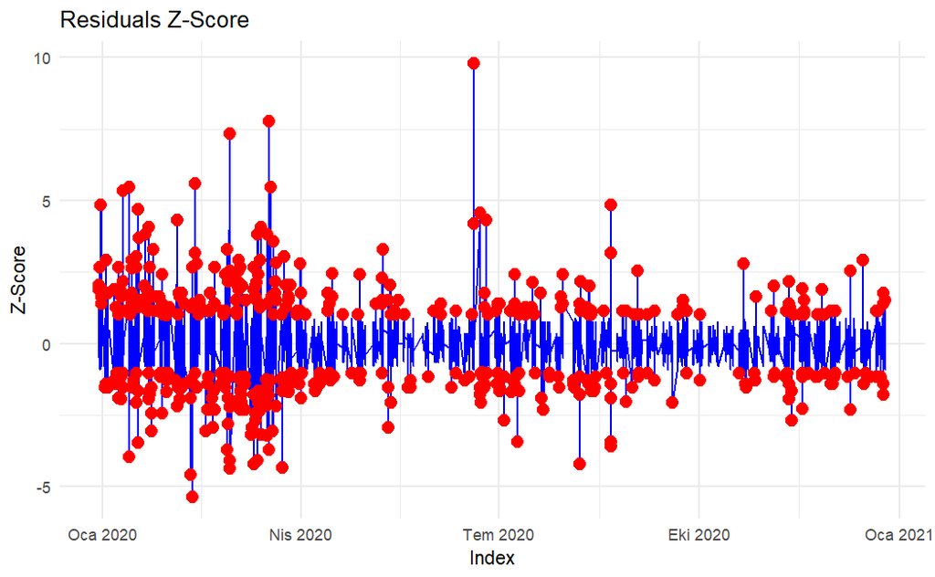

```r
#A plot of the Z-score is generated, with out-of-control reservoirs highlighted in a specific color and size.
library(ggplot2)
ggplot(combined_data, aes(x = timestamp, y = z_score)) +
  geom_line(color = "blue") +
  labs(title = "Residuals Z-Score",
       x = "Index",
       y = "Z-Score") +
  theme_minimal() +

  geom_point(data = out_of_control, aes(x = timestamp, y = z_score), color = "red", size = 3)
```

```r
NA
NA
```

Considering mean reversion tendencies, which stocks to sell and buy can be determined. The spread formula was previously calculated as: w_t= p_(1,t) -βˆp_(2,t)*. The algorithm used is the same as the one in task 1.When the spread exceeds the control limit, it indicates that the first stock in the pair is higher than the test value. To generate profits, the strategy involves selling the high-value stock and buying the low-value stock

```r
#Initial capital, the number of shares bought for AKBNK and YKBNK, and other variables are defined. A for loop is utilized to implement the pairs trading strategy.The results are printed on the screen, including initial capital, final capital, and profit percentage.
     money <- 1
     VAKBN_shares_bought <- 0
     AKBNK_shares_bought <- 0

          for (i in seq_along(combined_data$z_score)) {
                  # Buy signal for AKBNK
                  if (combined_data$z_score[i] > 0) {
                          if (VAKBN_shares_bought > 0) {
                                  money <- money + VAKBN_shares_bought * combined_data$VAKBN[i]
                                  VAKBN_shares_bought <- 0
                              }
                          if (money > 0 && combined_data$z_score[i] > 1) {
                                  AKBNK_shares_bought <- money / combined_data$AKBNK[i]
                                  money <- 0
                              }
                        # Buy signal for YKBNK
                      } else if (combined_data$z_score[i] < 0) {
                              if (AKBNK_shares_bought > 0) {
                                      money <- money + AKBNK_shares_bought * combined_data$AKBNK[i]
                                     AKBNK_shares_bought <- 0
                                  }
                              if (money > 0 && combined_data$z_score[i] < -1) {
                                      VAKBN_shares_bought <- money / combined_data$VAKBN[i]
                                      money <- 0
                                 }


                          }
              }

          money <- money + VAKBN_shares_bought * combined_data$VAKBN[length(combined_data$z_score)] + AKBNK_shares_bought * combined_data$AKBNK[length(combined_data$z_score)]

              cat(sprintf("AKBNK-VAKBN pair trading:\nStarting money: 1\nFinal money: %.2f\nProfit: %.2f%%\n", money, (money - 1) * 100))
```

```
AKBNK-VAKBN pair trading:
Starting money: 1
Final money: 1.18
Profit: 17.82%
```

**PAIR2 : ISCTR-AKBNK**

```r
#A new dataset named selected_columns is created, containing only the "timestamp," "ISCTR," and "AKBNK" columns.
selected_columns <- all_data[, c("timestamp", "ISCTR", "AKBNK")]
print(selected_columns)
```

| timestamp | ISCTR | AKBNK |
| --- | --- | --- |
| 2019-12-30 06:00:00 | 2.4619 | 7.0587 |
| 2019-12-30 07:00:00 | 2.5245 | 7.0844 |
| 2019-12-30 08:00:00 | 2.5323 | 7.0844 |
| 2019-12-30 09:00:00 | 2.5362 | 7.1186 |
| 2019-12-30 10:00:00 | 2.5167 | 7.1015 |
| 2019-12-30 11:00:00 | 2.5049 | 7.0844 |
| 2019-12-30 12:00:00 | 2.5128 | 7.1015 |
| 2019-12-30 13:00:00 | 2.5128 | 7.1015 |
| 2019-12-30 14:00:00 | 2.5206 | 7.0757 |
| 2019-12-30 15:00:00 | 2.5128 | 7.0929 |

[output cut: 990 more lines]

```r
#Differences in prices ("ISCTR" and "AKBNK") are calculated using the diff function, resulting in "ISCTR_diff" and "AKBNK_diff."
selected_columns$ISCTR_diff <- c(NA, diff(selected_columns$ISCTR))
selected_columns$AKBNK_diff <- c(NA, diff(selected_columns$AKBNK))
```

```r
# VAR model is applied to the differenced series, and a cointegration test is conducted.

diff_data <- data.frame(data1 = selected_columns$ISCTR_diff , data2 = selected_columns$AKBNK_diff )
diff_data<-na.omit(diff_data)

var_select <- VARselect(diff_data, lag.max = 25, type = "both")
lags<-var_select$selection["AIC(n)"]

co_test <- ca.jo(diff_data, type = "trace", K = lags, ecdet = "const")
summary(co_test)
```

```
######################
# Johansen-Procedure #
######################

Test type: trace statistic , without linear trend and constant in cointegration

Eigenvalues (lambda):
[1]  1.017822e-01  8.358324e-02 -1.387779e-17

Values of teststatistic and critical values of test:

           test 10pct  5pct  1pct
r <= 1 | 216.20  7.52  9.24 12.97
r = 0  | 482.09 17.85 19.96 24.60

Eigenvectors, normalised to first column:
(These are the cointegration relations)

              data1.l10     data2.l10   constant
data1.l10  1.0000000000  1.000000e+00  1.0000000
data2.l10 -0.4539719911 -2.444754e-02 -0.4214902
constant  -0.0003280575 -6.464028e-05  0.8560082

Weights W:
(This is the loading matrix)

         data1.l10  data2.l10      constant
data1.d -0.2989637 -0.9707506 -1.650231e-19
data2.d  2.2113597 -2.1953698  9.269804e-20
```

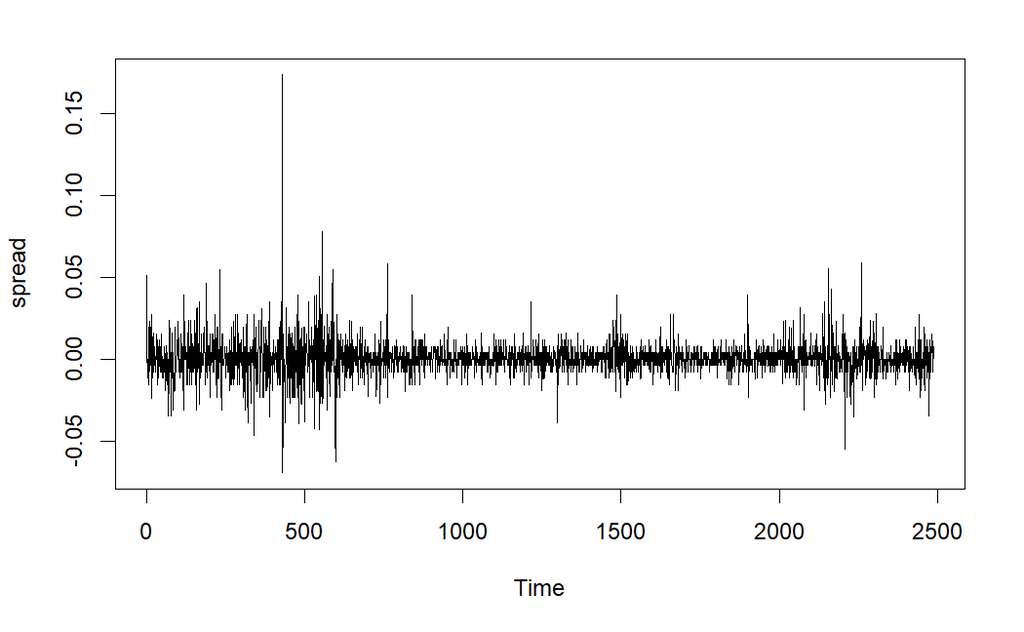

```r
#The spread is calculated using the VECM model, and a time series plot is generated to visualize the results.
vecm <- cajorls(co_test, r = 1)
diff_data_matrix <- as.matrix(diff_data)
spread <- diff_data_matrix %*% vecm$beta[1:2]
plot.ts(spread)
```

```r
selected_columns<-na.omit(selected_columns)
combined_data <- cbind(selected_columns, spread)
```

```r
# Z-scores are computed, and reservoirs exceeding predetermined threshold values (-1 and 1) are filtered out.
combined_data$z_score <- (combined_data$spread- mean(combined_data$ spread)) / sd(combined_data$ spread)

upper_limit <- 1
lower_limit <- -1
out_of_control <- combined_data[combined_data$z_score > upper_limit | combined_data$z_score < lower_limit, ]

#Print out-of-control residuals, timestamps, and stock prices
print(out_of_control[, c("timestamp", "z_score", "ISCTR", "AKBNK")])
```

|  | timestamp | z_score | ISCTR | AKBNK |
| --- | --- | --- | --- | --- |
| 2 | 2019-12-30 07:00:00 | 4.425163 | 2.5245 | 7.0844 |
| 4 | 2019-12-30 09:00:00 | -1.046918 | 2.5362 | 7.1186 |
| 5 | 2019-12-30 10:00:00 | -1.056648 | 2.5167 | 7.1015 |
| 9 | 2019-12-30 14:00:00 | 1.676783 | 2.5206 | 7.0757 |
| 10 | 2019-12-30 15:00:00 | -1.395270 | 2.5128 | 7.0929 |
| 13 | 2019-12-31 08:00:00 | 2.010706 | 2.5323 | 7.0587 |
| 17 | 2019-12-31 12:00:00 | 2.352207 | 2.5362 | 6.9901 |
| 18 | 2019-12-31 13:00:00 | 1.005408 | 2.5558 | 7.0072 |
| 19 | 2019-12-31 14:00:00 | -2.104041 | 2.5088 | 6.9559 |
| 21 | 2020-01-02 06:00:00 | -1.038899 | 2.5206 | 6.9987 |

[output cut: 494 more lines]

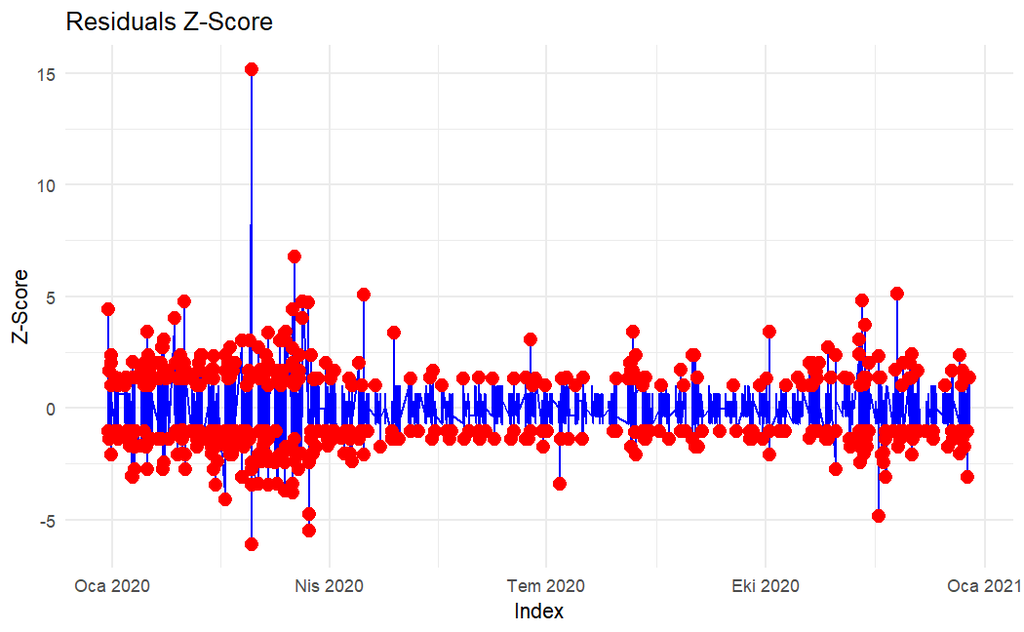

```r
#A plot of the Z-score is generated, with out-of-control reservoirs highlighted in a specific color and size.

ggplot(combined_data, aes(x = timestamp, y = z_score)) +
  geom_line(color = "blue") +
  labs(title = "Residuals Z-Score",
       x = "Index",
       y = "Z-Score") +
  theme_minimal() +

  geom_point(data = out_of_control, aes(x = timestamp, y = z_score), color = "red", size = 3)
```

```r
#Initial capital, the number of shares bought for AKBNK and YKBNK, and other variables are defined. A for loop is utilized to implement the pairs trading strategy.The results are printed on the screen, including initial capital, final capital, and profit percentage.
     money <- 1
     ISCTR_shares_bought <- 0
     AKBNK_shares_bought <- 0

          for (i in seq_along(combined_data$z_score)) {
                  # Buy signal for AKBNK
                  if (combined_data$z_score[i] > 0) {
                          if (ISCTR_shares_bought > 0) {
                                  money <- money + ISCTR_shares_bought * combined_data$ISCTR[i]
                                  ISCTR_shares_bought <- 0
                              }
                          if (money > 0 && combined_data$z_score[i] > 1) {
                                  AKBNK_shares_bought <- money / combined_data$AKBNK[i]
                                  money <- 0
                              }
                        # Buy signal for ISCTR
                      } else if (combined_data$z_score[i] < 0) {
                              if (AKBNK_shares_bought > 0) {
                                      money <- money + AKBNK_shares_bought * combined_data$AKBNK[i]
                                     AKBNK_shares_bought <- 0
                                  }
                              if (money > 0 && combined_data$z_score[i] < -1) {
                                      ISCTR_shares_bought <- money / combined_data$ISCTR[i]
                                      money <- 0
                                 }


                          }
              }

          money <- money + ISCTR_shares_bought * combined_data$ISCTR[length(combined_data$z_score)] + AKBNK_shares_bought * combined_data$AKBNK[length(combined_data$z_score)]

              cat(sprintf("AKBNK-ISCTR pair trading:\nStarting money: 1\nFinal money: %.2f\nProfit: %.2f%%\n", money, (money - 1) * 100))
```

```
AKBNK-ISCTR pair trading:
Starting money: 1
Final money: 1.79
Profit: 79.22%
```

**ANALYSIS & DISCUSSION**

Vector Error Correction Model is more complex to implement and interpret compared to the linear regression approach of task 1. The performance of the model is sensitive to the choice of parameters and incorrect parameters might lead to overfitting and inaccurate results. On the other hand, since it focuses on time dependencies and cointegration, long-term relationships can be captured more accurately.